# SI 618 Homework 9

### Overview

The purpose of this homework is to give you more experience with data aggregation in Python, visualization using plotnine, a grammar of graphics implementation almost identical to ggplot in R, and time-series analysis on a real-world dataset. You will be analyzing Wikipedia page popularity over an 18 month period from July 2015 to December 2016. The dataset is from (https://www.kaggle.com/c/web-traffic-time-series-forecasting/data), but we have provided the CSV (page_views.csv) for you. We have also provided an example document (si618_hw9_solution.html) of the intended solution.

## Question 0: Loading data and preprocessing (5 points)

Load the data (page_views.csv) and remove NA. (There are many ways to handle missing data, we choose to remove rows for the purpose of this assignment.)

## Question 1: Average Popularity Analysis (20 points)

#### Question 1-a: Plot the distribution of the average popularity of pages. (10 points)

Hint: You can use stat_ecdf of plotnine to plot a CDF (cumulative distribution function)

Hint2: You can use the mizani package to format the labels in the figure with commas.

Your plot should look something like this. Note that there is one data point that will be removed while creating this plot. This will happen due to the use of logarithmic scale. You can handle that in different ways. Given that this only affects one row, in this case we chose to ignore it. You can plot this distribution in linear scale first to see why logairthmic scale is needed.

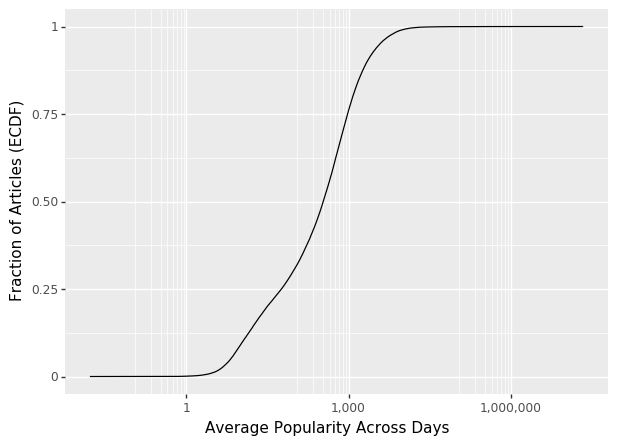

#### Question 1-b: What are the top-10 and bottom-10 pages with regards to popularity? (10 points)

```
Top 10 pages
                                                              Page  avg_popularity
                  Main_Page_en.wikipedia.org_all-access_all-agents        21938511
                     Main_Page_en.wikipedia.org_desktop_all-agents        15953632
                  Main_Page_en.wikipedia.org_mobile-web_all-agents         5734518
       Wikipedia:Hauptseite_de.wikipedia.org_all-access_all-agents         2916244
             Special:Search_en.wikipedia.org_all-access_all-agents         2371053
       Wikipedia:Hauptseite_de.wikipedia.org_mobile-web_all-agents         2023071
         Заглавная_страница_ru.wikipedia.org_all-access_all-agents         1974581
                Special:Search_en.wikipedia.org_desktop_all-agents         1839723
Wikipédia:Accueil_principal_fr.wikipedia.org_all-access_all-agents         1579056
          Wikipedia:Portada_es.wikipedia.org_all-access_all-agents         1366350
```

```
Bottom 10 pages
                                                                                  Page  avg_popularity
                             Special:EditWatchlist_www.mediawiki.org_all-access_spider       0.0000000
                               Especial:Seguimiento_es.wikipedia.org_all-access_spider       0.0163636
                        Служебная:Список_наблюдения_ru.wikipedia.org_all-access_spider       0.0200000
                         Special:EditWatchlist_commons.wikimedia.org_all-access_spider       0.0490909
                               Special:Preferences_www.mediawiki.org_all-access_spider       0.0509091
                            User:Willemnabuurs_commons.wikimedia.org_all-access_spider       0.0563636
                           Special:Preferences_commons.wikimedia.org_all-access_spider       0.0672727
                          User:JurgenNL/speedy_commons.wikimedia.org_all-access_spider       0.0690909
                           Special:OAuth/authorize_www.mediawiki.org_all-access_spider       0.0690909
User:Rotatebot/approx_max_wait_time_rotatelink_commons.wikimedia.org_all-access_spider       0.0890909
```

## Question 2: Day-of-the-week Effect (15 points)

Is there a day-of-the-week effect on Wikipedia? On average, which day sees the most Wikipedia views (total across all articles)? What about the least views?

```
      day     views
   Monday 191948745
   Sunday 186714034
  Tuesday 184840494
Wednesday 182450695
 Thursday 178039319
 Saturday 172645251
   Friday 172204777
```

## Question 3: Wikipedia views per day (30 points)

Plot Wikipedia views per day (total across all pages) over time. Then plot the de-seasonified data where the day-of-the-week effects are removed. Put those in the same plot using grid.arrange. (Note: You will need to change the figure width to see the plots properly. You dont have to match the exact same width we have here, just make sure it is readable.)

Hint: Use mizani package to get the correct formatting for the axis labels

```
Wikipedia Views Per Day
```

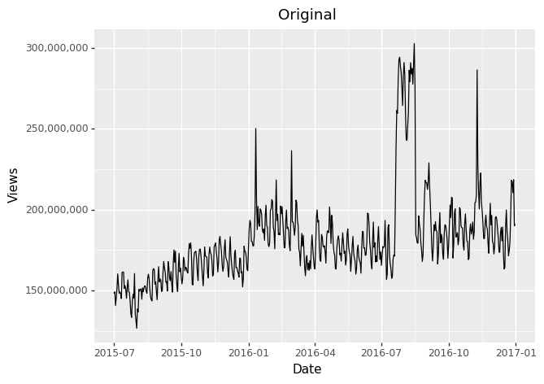

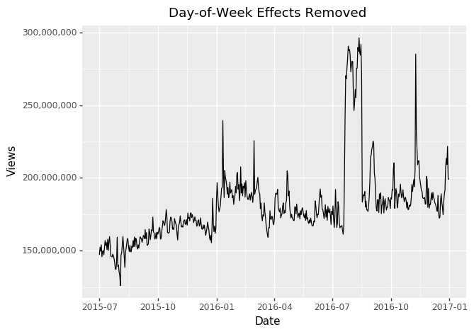

```
(<ggplot: (319709476)>, <ggplot: (321958769)>)
```

## Question 4: Repeat Q3 for the top 50K articles (30 points)

Repeat Q3 for the top 50K articles. For this you will need to first find the top 50K pages and limit your dataset to those. We define these top pages as those with the largest number of overall page views. Next you need to find the day of the week effect for this subset and plot the two time series.

```
Wikipedia Views Per Day - Top 50K articles
```

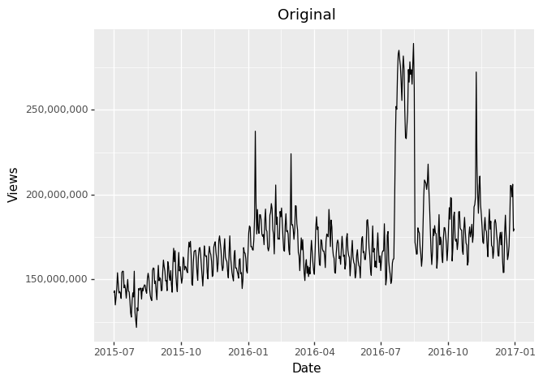

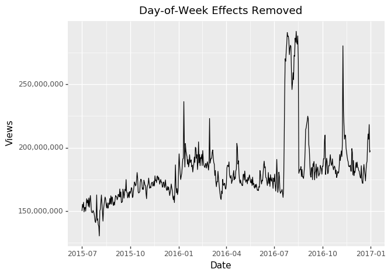

```
(<ggplot: (-9223372036539998085)>, <ggplot: (314777576)>)
```

## What to submit

- The jupyter notebook file named 'uniquename_si618_hw9_report.ipynb'
- The HTML or PDF report generated by your notebook file that should similar to si618_hw9_solution.html